# Ensemble Technique: Bagging and Boosting Project 4 - Travel Package Purhase

#### Variable 'Type of Contact' Analysis

```python
# Compute the percent of Type of contact values in each Type of contact group
data.groupby(['TypeofContact'])['CustomerID'].count()/len(data)*100
```

```
TypeofContact
Company Invited    29.030278
Self Enquiry       70.458265
Name: CustomerID, dtype: float64
```

```python
# Compute the number of data points in each Type of contact group
data.groupby(['TypeofContact'])['CustomerID'].count()
```

```
TypeofContact
Company Invited    1419
Self Enquiry       3444
Name: CustomerID, dtype: int64
```

```python
#Group Type of contact data by Product pitched
data.groupby(['TypeofContact'])['ProductPitched'].value_counts()
```

```
TypeofContact    ProductPitched
Company Invited  Deluxe             541
                 Basic              516
                 Standard           218
                 Super Deluxe        96
                 King                48
Self Enquiry     Basic             1316
                 Deluxe            1176
                 Standard           524
                 Super Deluxe       246
                 King               182
Name: ProductPitched, dtype: int64
```

```python
data['TypeofContact'].isnull().sum()
```

```
25
```

```python
# Impute null values with Product pitched group modes
data['TypeofContact']=data.groupby(['ProductPitched'], sort=False)['TypeofContact'].apply(lambda x: x.fillna(x.mode().iloc[0]))
```

```python
data['TypeofContact'].isnull().sum()
```

```
0
```

```python
data.groupby(['TypeofContact'])['ProductPitched'].value_counts()
```

```
TypeofContact    ProductPitched
Company Invited  Deluxe             541
                 Basic              516
                 Standard           218
                 Super Deluxe        96
                 King                48
Self Enquiry     Basic             1326
                 Deluxe            1191
                 Standard           524
                 Super Deluxe       246
                 King               182
Name: ProductPitched, dtype: int64
```

```python
data.groupby(['TypeofContact'])['ProductPitched'].value_counts(normalize = True)*100
```

```
TypeofContact    ProductPitched
Company Invited  Deluxe            38.125440
                 Basic             36.363636
                 Standard          15.362932
                 Super Deluxe       6.765328
                 King               3.382664
Self Enquiry     Basic             38.224272
                 Deluxe            34.332661
                 Standard          15.105218
                 Super Deluxe       7.091381
                 King               5.246469
Name: ProductPitched, dtype: float64
```

```python
# Compute the number of products purchased by product pitched
data.groupby(['ProductPitched','ProdTaken'])['TypeofContact'].value_counts()
```

```
ProductPitched  ProdTaken  TypeofContact
Basic           0          Self Enquiry        968
                           Company Invited     322
                1          Self Enquiry        358
                           Company Invited     194
Deluxe          0          Self Enquiry       1055
                           Company Invited     473
                1          Self Enquiry        136
                           Company Invited      68
King            0          Self Enquiry        162
                           Company Invited      48
                1          Self Enquiry         20
Standard        0          Self Enquiry        432
                           Company Invited     186
                1          Self Enquiry         92
                           Company Invited      32
Super Deluxe    0          Self Enquiry        242
                           Company Invited      80
                1          Company Invited      16
                           Self Enquiry          4
Name: TypeofContact, dtype: int64
```

```python
data.groupby(['TypeofContact'])['ProdTaken'].value_counts(normalize = True)*100
```

```
TypeofContact    ProdTaken
Company Invited  0            78.153629
                 1            21.846371
Self Enquiry     0            82.415682
                 1            17.584318
Name: ProdTaken, dtype: float64
```

```python
# Compute the number of products purchased by product pitched
data.groupby(['ProductPitched','ProdTaken'])['TypeofContact'].value_counts(normalize=True)*100
```

```
ProductPitched  ProdTaken  TypeofContact
Basic           0          Self Enquiry        75.038760
                           Company Invited     24.961240
                1          Self Enquiry        64.855072
                           Company Invited     35.144928
Deluxe          0          Self Enquiry        69.044503
                           Company Invited     30.955497
                1          Self Enquiry        66.666667
                           Company Invited     33.333333
King            0          Self Enquiry        77.142857
                           Company Invited     22.857143
                1          Self Enquiry       100.000000
Standard        0          Self Enquiry        69.902913
                           Company Invited     30.097087
                1          Self Enquiry        74.193548
                           Company Invited     25.806452
Super Deluxe    0          Self Enquiry        75.155280
                           Company Invited     24.844720
                1          Company Invited     80.000000
                           Self Enquiry        20.000000
Name: TypeofContact, dtype: float64
```

#### Insights - 'TypeofContact'

- 25 null values imputed with mode given Product Pitched
- Customers who self-inquiry (71%) outnumber customers (29%) who are invited by the company
- Both types of customers are initially pitched Basic and Deluxe products (although self-inquiry are pitched slightly more Basic than Deluxe and vice versa for company invited)
- Product pitch percentages are not greatly impacted by type of contact; percentages are similar with exception of Basic and Deluxe varying slightly; Self-enquiry favors Basic whereas Company invited favors Deluxe
- Out of those who take the Basic product, 65% are self-enquiry and 35% are company invited
- Out of those who take the Deluxe product,67% are self-enquiry and 33% are company invited
- Out of those who take the King product, 100 are self-inquiry
- Out of those who take the standard product, 74% are self enquiry and 26% are Company invited
- Out of those who take the Super Deluxe product, 80% are company invited and 20% are self-enquiry
- King, standard and Super Deluxe sales numbers for sales enquiry outpace the number of self enquiry. (These are likely up sales)

#### Variable 'CityTier' Analysis

```python
# Compute the number of data points in each CityTier group
data.groupby(['CityTier'])['CustomerID'].count()
```

```
CityTier
1    3190
2     198
3    1500
Name: CustomerID, dtype: int64
```

```python
# Compute the percent of Type of contact values in each CityTier group
data.groupby(['CityTier'])['CustomerID'].count()/len(data)*100
```

```
CityTier
1    65.261866
2     4.050736
3    30.687398
Name: CustomerID, dtype: float64
```

```python
#Group CityTier data by Product pitched
data.groupby(['CityTier'])['ProductPitched'].value_counts()
```

```
CityTier  ProductPitched
1         Basic             1466
          Deluxe             908
          Standard           436
          Super Deluxe       212
          King               168
2         Basic              108
          Deluxe              40
          King                22
          Standard            18
          Super Deluxe        10
3         Deluxe             784
          Standard           288
          Basic              268
          Super Deluxe       120
          King                40
Name: ProductPitched, dtype: int64
```

```python
data.groupby(['CityTier'])['ProductPitched'].value_counts(normalize=True)*100
```

```
CityTier  ProductPitched
1         Basic             45.956113
          Deluxe            28.463950
          Standard          13.667712
          Super Deluxe       6.645768
          King               5.266458
2         Basic             54.545455
          Deluxe            20.202020
          King              11.111111
          Standard           9.090909
          Super Deluxe       5.050505
3         Deluxe            52.266667
          Standard          19.200000
          Basic             17.866667
          Super Deluxe       8.000000
          King               2.666667
Name: ProductPitched, dtype: float64
```

```python
# Compute the number of products purchased by product pitched
data.groupby(['ProductPitched','ProdTaken'])['CityTier'].value_counts()
```

```
ProductPitched  ProdTaken  CityTier
Basic           0          1           1074
                           3            146
                           2             70
                1          1            392
                           3            122
                           2             38
Deluxe          0          1            848
                           3            640
                           2             40
                1          3            144
                           1             60
King            0          1            156
                           3             32
                           2             22
                1          1             12
                           3              8
Standard        0          1            384
                           3            224
                           2             10
                1          3             64
                           1             52
                           2              8
Super Deluxe    0          1            208
                           3            104
                           2             10
                1          3             16
                           1              4
Name: CityTier, dtype: int64
```

```python
# Compute the percentages of products purchased by product pitched
data.groupby(['ProductPitched','ProdTaken'])['CityTier'].value_counts(normalize=True)*100
```

```
ProductPitched  ProdTaken  CityTier
Basic           0          1           83.255814
                           3           11.317829
                           2            5.426357
                1          1           71.014493
                           3           22.101449
                           2            6.884058
Deluxe          0          1           55.497382
                           3           41.884817
                           2            2.617801
                1          3           70.588235
                           1           29.411765
King            0          1           74.285714
                           3           15.238095
                           2           10.476190
                1          1           60.000000
                           3           40.000000
Standard        0          1           62.135922
                           3           36.245955
                           2            1.618123
                1          3           51.612903
                           1           41.935484
                           2            6.451613
Super Deluxe    0          1           64.596273
                           3           32.298137
                           2            3.105590
                1          3           80.000000
                           1           20.000000
Name: CityTier, dtype: float64
```

#### Insights - City Tier

- CityTier 1 - Product pitched - 46% Basic and 28% Deluxe
- City Tier 2 is similar to City Tier 1 with 55% Basic and 20% Deluxe
- City Tier 3 is different from City Tier 1 and City Tier 2 with 52% Deluxe and 19% Standard; Basic accounts for 18% of products pitched

#### Variable 'Occupation' Analysis

```python
# Compute the number of data points in each Occupation group
data.groupby(['Occupation'])['CustomerID'].count()
```

```
Occupation
Free Lancer          2
Large Business     434
Salaried          2368
Small Business    2084
Name: CustomerID, dtype: int64
```

```python
# Compute the percent of Occupation values in each group
data.groupby(['Occupation'])['CustomerID'].count()/len(data)*100
```

```
Occupation
Free Lancer        0.040917
Large Business     8.878887
Salaried          48.445172
Small Business    42.635025
Name: CustomerID, dtype: float64
```

```python
#Group Occupation data by Product pitched
data.groupby(['Occupation'])['ProductPitched'].value_counts()
```

```
Occupation      ProductPitched
Free Lancer     Basic               2
Large Business  Basic             196
                Deluxe            124
                Standard           84
                Super Deluxe       18
                King               12
Salaried        Basic             924
                Deluxe            818
                Standard          338
                Super Deluxe      174
                King              114
Small Business  Deluxe            790
                Basic             720
                Standard          320
                Super Deluxe      150
                King              104
Name: ProductPitched, dtype: int64
```

```python
data.groupby(['Occupation'])['ProductPitched'].value_counts(normalize=True)*100
```

```
Occupation      ProductPitched
Free Lancer     Basic             100.000000
Large Business  Basic              45.161290
                Deluxe             28.571429
                Standard           19.354839
                Super Deluxe        4.147465
                King                2.764977
Salaried        Basic              39.020270
                Deluxe             34.543919
                Standard           14.273649
                Super Deluxe        7.347973
                King                4.814189
Small Business  Deluxe             37.907869
                Basic              34.548944
                Standard           15.355086
                Super Deluxe        7.197697
                King                4.990403
Name: ProductPitched, dtype: float64
```

```python
data.groupby(['Occupation'])['ProdTaken'].value_counts(normalize=True)*100
```

```
Occupation      ProdTaken
Free Lancer     1            100.000000
Large Business  0             72.350230
                1             27.649770
Salaried        0             82.516892
                1             17.483108
Small Business  0             81.573896
                1             18.426104
Name: ProdTaken, dtype: float64
```

#### Variable 'Gender' Analysis

```python
# Compute the number of data points in each Gender group
data.groupby(['Gender'])['CustomerID'].count()
```

```
Gender
Fe Male     155
Female     1817
Male       2916
Name: CustomerID, dtype: int64
```

```python
#Replace Fe Male with 'Female'
data['Gender'].replace('Fe Male','Female', regex = True, inplace =True)
```

```python
#Check results of replacement
data.groupby(['Gender'])['CustomerID'].count()
```

```
Gender
Female    1972
Male      2916
Name: CustomerID, dtype: int64
```

```python
data['Gender'].value_counts(normalize=True)*100
```

```
Male      59.656301
Female    40.343699
Name: Gender, dtype: float64
```

```python
#Group CityTier data by Product pitched
data.groupby(['Gender'])['ProductPitched'].value_counts()
```

```
Gender  ProductPitched
Female  Deluxe             724
        Basic              680
        Standard           326
        Super Deluxe       160
        King                82
Male    Basic             1162
        Deluxe            1008
        Standard           416
        Super Deluxe       182
        King               148
Name: ProductPitched, dtype: int64
```

```python
#Group CityTier data by Product pitched
data.groupby(['Gender'])['ProductPitched'].value_counts(normalize = True)*100
```

```
Gender  ProductPitched
Female  Deluxe            36.713996
        Basic             34.482759
        Standard          16.531440
        Super Deluxe       8.113590
        King               4.158215
Male    Basic             39.849108
        Deluxe            34.567901
        Standard          14.266118
        Super Deluxe       6.241427
        King               5.075446
Name: ProductPitched, dtype: float64
```

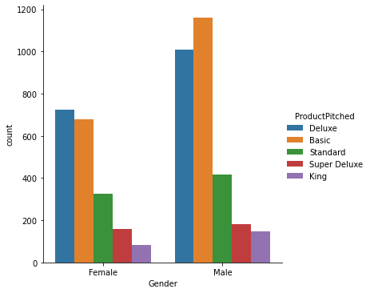

```python
#Use a stack bar graph to explore relationahip between gender and prodct pitched
sns.catplot(x='Gender', data = data, kind = 'count', hue = 'ProductPitched')
```

```python
# Compute the number of products purchased by product pitched
data.groupby(['ProductPitched','ProdTaken'])['Gender'].value_counts()
```

```
ProductPitched  ProdTaken  Gender
Basic           0          Male      818
                           Female    472
                1          Male      344
                           Female    208
Deluxe          0          Male      874
                           Female    654
                1          Male      134
                           Female     70
King            0          Male      140
                           Female     70
                1          Female     12
                           Male        8
Standard        0          Male      340
                           Female    278
                1          Male       76
                           Female     48
Super Deluxe    0          Male      166
                           Female    156
                1          Male       16
                           Female      4
Name: Gender, dtype: int64
```

```python
# Compute the percentages of products purchased by product pitched
data.groupby(['ProductPitched','ProdTaken'])['Gender'].value_counts(normalize=True)*100
```

```
ProductPitched  ProdTaken  Gender
Basic           0          Male      63.410853
                           Female    36.589147
                1          Male      62.318841
                           Female    37.681159
Deluxe          0          Male      57.198953
                           Female    42.801047
                1          Male      65.686275
                           Female    34.313725
King            0          Male      66.666667
                           Female    33.333333
                1          Female    60.000000
                           Male      40.000000
Standard        0          Male      55.016181
                           Female    44.983819
                1          Male      61.290323
                           Female    38.709677
Super Deluxe    0          Male      51.552795
                           Female    48.447205
                1          Male      80.000000
                           Female    20.000000
Name: Gender, dtype: float64
```

```python
data.groupby(['ProductPitched','ProdTaken'])['Gender'].value_counts(normalize=True)*100
```

```
ProductPitched  ProdTaken  Gender
Basic           0          Male      63.410853
                           Female    36.589147
                1          Male      62.318841
                           Female    37.681159
Deluxe          0          Male      57.198953
                           Female    42.801047
                1          Male      65.686275
                           Female    34.313725
King            0          Male      66.666667
                           Female    33.333333
                1          Female    60.000000
                           Male      40.000000
Standard        0          Male      55.016181
                           Female    44.983819
                1          Male      61.290323
                           Female    38.709677
Super Deluxe    0          Male      51.552795
                           Female    48.447205
                1          Male      80.000000
                           Female    20.000000
Name: Gender, dtype: float64
```

```python
data.groupby(['Gender'])['ProdTaken'].value_counts(normalize=True)*100
```

```
Gender  ProdTaken
Female  0            82.657201
        1            17.342799
Male    0            80.178326
        1            19.821674
Name: ProdTaken, dtype: float64
```

#### Variable "Number of Persons Visiting" Analysis

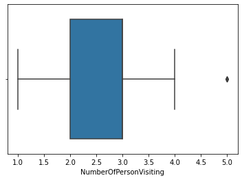

```python
sns.boxplot(data=data, x='NumberOfPersonVisiting')
```

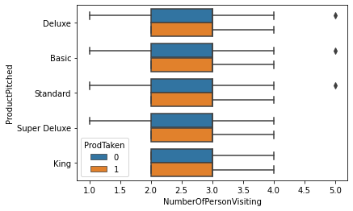

```python
sns.boxplot(data=data, x='NumberOfPersonVisiting', y='ProductPitched', hue='ProdTaken')
```

```python
data['NumberOfPersonVisiting'].value_counts()
```

```
3    2402
2    1418
4    1026
1      39
5       3
Name: NumberOfPersonVisiting, dtype: int64
```

```python
data['NumberOfPersonVisiting'].value_counts(normalize=True)*100
```

```
3    49.140753
2    29.009820
4    20.990180
1     0.797872
5     0.061375
Name: NumberOfPersonVisiting, dtype: float64
```

```python
# Compute the number of products purchased by product pitched
data.groupby(['ProductPitched','ProdTaken'])['NumberOfPersonVisiting'].value_counts()
```

```
ProductPitched  ProdTaken  NumberOfPersonVisiting
Basic           0          3                         635
                           2                         353
                           4                         292
                           1                           9
                           5                           1
                1          3                         276
                           2                         164
                           4                         112
Deluxe          0          3                         746
                           2                         455
                           4                         309
                           1                          17
                           5                           1
                1          3                         102
```

[output cut: 24 more lines]

```python
# Compute the number of products purchased by product pitched
data.groupby(['ProductPitched','ProdTaken'])['NumberOfPersonVisiting'].value_counts(normalize=True)*100
```

```
ProductPitched  ProdTaken  NumberOfPersonVisiting
Basic           0          3                         49.224806
                           2                         27.364341
                           4                         22.635659
                           1                          0.697674
                           5                          0.077519
                1          3                         50.000000
                           2                         29.710145
                           4                         20.289855
Deluxe          0          3                         48.821990
                           2                         29.777487
                           4                         20.222513
                           1                          1.112565
                           5                          0.065445
                1          3                         50.000000
```

[output cut: 24 more lines]

#### Insights - 'Number of Person Visiting'

- Values 1 and 5 appear to be outliers
- most impactful values for determining product taken is 2 and 3, which account for almost 80% of the values
- For Products taken: Ratios of Number of Persons Visiting: Percentage Product taken - Basic:3:50%, 2:30%, 4:20% (similar to base ratio); Deluxe: 3:50%, 2:27%; 4:23%; King - 3:50%; 2:30%; 4:20 (similar to base ratio); Standard - 3:50%; 2:27%; 4:23% (similar to base ratio); Super Deluxe - 3:50%, 2:40%,4:10% (varies slightly from base ratio but likely not enough for major impact

This variable does not appear to impact customer taking product pitched; will test feature impact during modeling

#### Variable 'Preferred Property Star' Analysis

```python
data['PreferredPropertyStar'].value_counts()
```

```
3.0    2993
5.0     956
4.0     913
Name: PreferredPropertyStar, dtype: int64
```

```python
data['PreferredPropertyStar'].value_counts(normalize=True)*100
```

```
3.0    61.559029
5.0    19.662690
4.0    18.778281
Name: PreferredPropertyStar, dtype: float64
```

```python
#Group Preferred Property Star data by Product pitched
data.groupby(['PreferredPropertyStar'])['ProductPitched'].value_counts()
```

```
PreferredPropertyStar  ProductPitched
3.0                    Basic             1118
                       Deluxe            1090
                       Standard           436
                       Super Deluxe       212
                       King               137
4.0                    Basic              368
                       Deluxe             312
                       Standard           130
                       Super Deluxe        62
                       King                41
5.0                    Basic              355
                       Deluxe             329
                       Standard           175
                       Super Deluxe        68
                       King                29
Name: ProductPitched, dtype: int64
```

```python
#Group Preferred Property Star data by Product pitched
data.groupby(['PreferredPropertyStar'])['ProductPitched'].value_counts(normalize = True)*100
```

```
PreferredPropertyStar  ProductPitched
3.0                    Basic             37.353826
                       Deluxe            36.418309
                       Standard          14.567324
                       Super Deluxe       7.083194
                       King               4.577347
4.0                    Basic             40.306681
                       Deluxe            34.173056
                       Standard          14.238773
                       Super Deluxe       6.790800
                       King               4.490690
5.0                    Basic             37.133891
                       Deluxe            34.414226
                       Standard          18.305439
                       Super Deluxe       7.112971
                       King               3.033473
Name: ProductPitched, dtype: float64
```

```python
#Locate the rows where Preferred Property Star is Null
PPSNull = data[data['PreferredPropertyStar'].isna()]
PPSNull.shape
```

```
(26, 20)
```

```python
PPSNull
```

|  | CustomerID | ProdTaken | Age | TypeofContact | CityTier | DurationOfPitch | Occupation | Gender | NumberOfPersonVisiting | NumberOfFollowups | ProductPitched | PreferredPropertyStar | MaritalStatus | NumberOfTrips | Passport | PitchSatisfactionScore | OwnCar | NumberOfChildrenVisiting | Designation | MonthlyIncome |
| --- | --- | --- | --- | --- | --- | --- | --- | --- | --- | --- | --- | --- | --- | --- | --- | --- | --- | --- | --- | --- |
| 38 | 200038 | 0 | 36.0 | Self Enquiry | 1 | 11.0 | Salaried | Female | 2 | 4.0 | Basic | NaN | Divorced | 1.0 | 1 | 2 | 1 | 0.0 | Executive | 95000.0 |
| 2609 | 202609 | 0 | 51.0 | Self Enquiry | 1 | 18.0 | Salaried | Female | 3 | 4.0 | King | NaN | Single | 5.0 | 0 | 5 | 1 | 1.0 | VP | 38604.0 |
| 2634 | 202634 | 0 | 53.0 | Self Enquiry | 1 | 7.0 | Salaried | Male | 4 | 5.0 | King | NaN | Divorced | 2.0 | 0 | 2 | 1 | 2.0 | VP | 38677.0 |
| 3012 | 203012 | 1 | 56.0 | Self Enquiry | 1 | 9.0 | Small Business | Male | 4 | 4.0 | King | NaN | Divorced | 7.0 | 1 | 2 | 1 | 3.0 | VP | 38537.0 |
| 3190 | 203190 | 0 | 42.0 | Company Invited | 1 | 14.0 | Salaried | Female | 3 | 6.0 | King | NaN | Married | 3.0 | 0 | 4 | 1 | 1.0 | VP | 38651.0 |
| 3193 | 203193 | 1 | 53.0 | Self Enquiry | 3 | 9.0 | Small Business | Female | 3 | 6.0 | King | NaN | Divorced | 3.0 | 0 | 3 | 1 | 1.0 | VP | 38523.0 |
| 3214 | 203214 | 0 | 47.0 | Self Enquiry | 1 | 7.0 | Small Business | Male | 3 | 4.0 | King | NaN | Married | 2.0 | 0 | 5 | 1 | 2.0 | VP | 38305.0 |
| 3295 | 203295 | 0 | 57.0 | Self Enquiry | 1 | 11.0 | Large Business | Female | 4 | 4.0 | King | NaN | Married | 6.0 | 0 | 4 | 0 | 3.0 | VP | 38621.0 |
| 3342 | 203342 | 0 | 44.0 | Self Enquiry | 1 | 10.0 | Salaried | Male | 4 | 6.0 | King | NaN | Divorced | 5.0 | 0 | 5 | 1 | 3.0 | VP | 38418.0 |
| 3362 | 203362 | 0 | 52.0 | Company Invited | 3 | 16.0 | Salaried | Male | 3 | 4.0 | King | NaN | Married | 6.0 | 1 | 4 | 1 | 2.0 | VP | 38525.0 |
| 3400 | 203400 | 0 | 57.0 | Self Enquiry | 2 | 15.0 | Salaried | Male | 3 | 4.0 | King | NaN | Single | 8.0 | 0 | 4 | 1 | 1.0 | VP | 38395.0 |
| 3453 | 203453 | 0 | 59.0 | Self Enquiry | 1 | 7.0 | Small Business | Female | 4 | 4.0 | King | NaN | Divorced | 5.0 | 1 | 1 | 1 | 3.0 | VP | 38379.0 |
| 3598 | 203598 | 0 | 48.0 | Self Enquiry | 2 | 33.0 | Salaried | Female | 4 | 4.0 | King | NaN | Married | 5.0 | 0 | 4 | 1 | 2.0 | VP | 38336.0 |
| 3686 | 203686 | 0 | 41.0 | Self Enquiry | 3 | 14.0 | Small Business | Male | 3 | 4.0 | King | NaN | Single | 3.0 | 0 | 4 | 1 | 2.0 | VP | 38511.0 |
| 3775 | 203775 | 0 | 49.0 | Self Enquiry | 1 | 17.0 | Salaried | Male | 4 | 5.0 | King | NaN | Married | 6.0 | 0 | 3 | 1 | 2.0 | VP | 38343.0 |
| 3845 | 203845 | 0 | 56.0 | Self Enquiry | 2 | 33.0 | Salaried | Male | 4 | 2.0 | King | NaN | Married | 6.0 | 1 | 5 | 1 | 3.0 | VP | 38314.0 |
| 4079 | 204079 | 0 | 51.0 | Self Enquiry | 1 | 18.0 | Salaried | Female | 3 | 4.0 | King | NaN | Single | 5.0 | 0 | 5 | 0 | 2.0 | VP | 38604.0 |
| 4104 | 204104 | 0 | 53.0 | Self Enquiry | 1 | 7.0 | Salaried | Male | 4 | 5.0 | King | NaN | Married | 2.0 | 0 | 1 | 1 | 3.0 | VP | 38677.0 |
| 4482 | 204482 | 1 | 56.0 | Self Enquiry | 1 | 9.0 | Small Business | Male | 4 | 4.0 | King | NaN | Married | 7.0 | 1 | 1 | 1 | 1.0 | VP | 38537.0 |
| 4660 | 204660 | 0 | 42.0 | Company Invited | 1 | 14.0 | Salaried | Female | 3 | 6.0 | King | NaN | Married | 3.0 | 0 | 4 | 1 | 2.0 | VP | 38651.0 |
| 4663 | 204663 | 1 | 53.0 | Self Enquiry | 3 | 9.0 | Small Business | Female | 3 | 6.0 | King | NaN | Married | 3.0 | 0 | 3 | 1 | 2.0 | VP | 38523.0 |
| 4684 | 204684 | 0 | 47.0 | Self Enquiry | 1 | 7.0 | Small Business | Male | 3 | 4.0 | King | NaN | Married | 2.0 | 0 | 5 | 1 | 1.0 | VP | 38305.0 |
| 4765 | 204765 | 0 | 57.0 | Self Enquiry | 1 | 11.0 | Large Business | Female | 4 | 4.0 | King | NaN | Married | 6.0 | 0 | 4 | 1 | 2.0 | VP | 38621.0 |
| 4812 | 204812 | 0 | 44.0 | Self Enquiry | 1 | 10.0 | Salaried | Male | 4 | 6.0 | King | NaN | Married | 5.0 | 0 | 5 | 1 | 1.0 | VP | 38418.0 |
| 4832 | 204832 | 1 | 52.0 | Company Invited | 1 | 35.0 | Salaried | Male | 4 | 5.0 | Deluxe | NaN | Single | 5.0 | 0 | 3 | 0 | 1.0 | Manager | 38525.0 |
| 4870 | 204870 | 1 | 57.0 | Self Enquiry | 3 | 23.0 | Salaried | Female | 4 | 4.0 | Standard | NaN | Single | 4.0 | 1 | 5 | 1 | 3.0 | Senior Manager | 38395.0 |

```python
#Group Preferred Property Star data by Product pitched
data.groupby(['ProductPitched'])['PreferredPropertyStar'].median()
```

```
ProductPitched
Basic           3.0
Deluxe          3.0
King            3.0
Standard        3.0
Super Deluxe    3.0
Name: PreferredPropertyStar, dtype: float64
```

```python
#Impute Median (3) for Null values
data['PreferredPropertyStar'] = data.groupby(['ProductPitched'], sort=False)['PreferredPropertyStar'].apply(lambda x: x.fillna(x.median()))

data['PreferredPropertyStar'].isnull().sum()
```

```
0
```

```python
# Compute the number of products purchased by product pitched
data.groupby(['ProductPitched','ProdTaken'])['PreferredPropertyStar'].value_counts()
```

```
ProductPitched  ProdTaken  PreferredPropertyStar
Basic           0          3.0                      837
                           4.0                      254
                           5.0                      199
                1          3.0                      282
                           5.0                      156
                           4.0                      114
Deluxe          0          3.0                      976
                           4.0                      276
                           5.0                      276
                1          3.0                      115
                           5.0                       53
                           4.0                       36
King            0          3.0                      150
                           4.0                       33
                           5.0                       27
                1          3.0                       10
                           4.0                        8
                           5.0                        2
Standard        0          3.0                      368
                           5.0                      140
                           4.0                      110
                1          3.0                       69
                           5.0                       35
                           4.0                       20
Super Deluxe    0          3.0                      200
                           5.0                       64
                           4.0                       58
                1          3.0                       12
                           4.0                        4
                           5.0                        4
Name: PreferredPropertyStar, dtype: int64
```

```python
data.groupby(['ProductPitched','ProdTaken'])['PreferredPropertyStar'].value_counts(normalize=True)*100
```

```
ProductPitched  ProdTaken  PreferredPropertyStar
Basic           0          3.0                      64.883721
                           4.0                      19.689922
                           5.0                      15.426357
                1          3.0                      51.086957
                           5.0                      28.260870
                           4.0                      20.652174
Deluxe          0          3.0                      63.874346
                           4.0                      18.062827
                           5.0                      18.062827
                1          3.0                      56.372549
                           5.0                      25.980392
                           4.0                      17.647059
King            0          3.0                      71.428571
                           4.0                      15.714286
                           5.0                      12.857143
                1          3.0                      50.000000
                           4.0                      40.000000
                           5.0                      10.000000
Standard        0          3.0                      59.546926
                           5.0                      22.653722
                           4.0                      17.799353
                1          3.0                      55.645161
                           5.0                      28.225806
                           4.0                      16.129032
Super Deluxe    0          3.0                      62.111801
                           5.0                      19.875776
                           4.0                      18.012422
                1          3.0                      60.000000
                           4.0                      20.000000
                           5.0                      20.000000
Name: PreferredPropertyStar, dtype: float64
```

```python
data.groupby(['ProdTaken'])['PreferredPropertyStar'].value_counts(normalize=True)*100
```

```
ProdTaken  PreferredPropertyStar
0          3.0                      63.785282
           4.0                      18.422379
           5.0                      17.792339
1          3.0                      53.043478
           5.0                      27.173913
           4.0                      19.782609
Name: PreferredPropertyStar, dtype: float64
```

```python
data.groupby(['PreferredPropertyStar'])['ProdTaken'].value_counts(normalize=True)*100
```

```
PreferredPropertyStar  ProdTaken
3.0                    0            83.835707
                       1            16.164293
4.0                    0            80.065717
                       1            19.934283
5.0                    0            73.849372
                       1            26.150628
Name: ProdTaken, dtype: float64
```

```python
data.groupby(['ProductPitched','ProdTaken'])['PreferredPropertyStar'].value_counts(normalize=True)*100
```

```
ProductPitched  ProdTaken  PreferredPropertyStar
Basic           0          3.0                      64.883721
                           4.0                      19.689922
                           5.0                      15.426357
                1          3.0                      51.086957
                           5.0                      28.260870
                           4.0                      20.652174
Deluxe          0          3.0                      63.874346
                           4.0                      18.062827
                           5.0                      18.062827
                1          3.0                      56.372549
                           5.0                      25.980392
                           4.0                      17.647059
King            0          3.0                      71.428571
                           4.0                      15.714286
                           5.0                      12.857143
                1          3.0                      50.000000
                           4.0                      40.000000
                           5.0                      10.000000
Standard        0          3.0                      59.546926
                           5.0                      22.653722
                           4.0                      17.799353
                1          3.0                      55.645161
                           5.0                      28.225806
                           4.0                      16.129032
Super Deluxe    0          3.0                      62.111801
                           5.0                      19.875776
                           4.0                      18.012422
                1          3.0                      60.000000
                           4.0                      20.000000
                           5.0                      20.000000
Name: PreferredPropertyStar, dtype: float64
```